# 2018201743-张嘉辰-第一周作业

张嘉辰

2020年9月11日

## A.3

```r
library(MASS)
attach(geyser)
Tless <- geyser[waiting<70, ]
print('(1)等待时间70min以下的数据:')
```

```
## [1] "(1)等待时间70min以下的数据:"
```

```r
#以表格形式输出
knitr::kable(Tless, format = "html")
```

|  | waiting | duration |
| --- | --- | --- |
| 3 | 57 | 4.000000 |
| 7 | 60 | 4.383333 |
| 10 | 56 | 4.833333 |
| 12 | 50 | 5.450000 |
| 14 | 54 | 4.866667 |
| 17 | 60 | 4.666667 |
| 19 | 65 | 4.733333 |
| 22 | 54 | 4.966667 |
| 24 | 58 | 4.000000 |
| 26 | 57 | 4.000000 |
| 28 | 68 | 4.500000 |
| 34 | 65 | 4.883333 |
| 36 | 58 | 4.150000 |
| 38 | 50 | 4.766667 |
| 40 | 48 | 4.600000 |
| 42 | 54 | 4.133333 |
| 44 | 53 | 4.000000 |
| 46 | 52 | 4.000000 |
| 48 | 60 | 4.266667 |
| 50 | 49 | 4.466667 |
| 52 | 60 | 4.000000 |
| 54 | 43 | 4.333333 |
| 56 | 60 | 4.483333 |
| 58 | 69 | 3.333333 |
| 62 | 50 | 5.266667 |
| 64 | 57 | 4.000000 |
| 66 | 61 | 4.000000 |
| 68 | 48 | 4.000000 |
| 71 | 62 | 4.500000 |
| 73 | 54 | 4.150000 |

[output cut: 78 more lines]

```r
TlessWnequal <- geyser[waiting<70 & waiting != 57, ]
print("(2)等待时间70min以下且不等于57min的数据")
```

```
## [1] "(2)等待时间70min以下且不等于57min的数据"
```

```r
#以表格形式输出
knitr::kable(TlessWnequal, format = "html")
```

|  | waiting | duration |
| --- | --- | --- |
| 7 | 60 | 4.383333 |
| 10 | 56 | 4.833333 |
| 12 | 50 | 5.450000 |
| 14 | 54 | 4.866667 |
| 17 | 60 | 4.666667 |
| 19 | 65 | 4.733333 |
| 22 | 54 | 4.966667 |
| 24 | 58 | 4.000000 |
| 28 | 68 | 4.500000 |
| 34 | 65 | 4.883333 |
| 36 | 58 | 4.150000 |
| 38 | 50 | 4.766667 |
| 40 | 48 | 4.600000 |
| 42 | 54 | 4.133333 |
| 44 | 53 | 4.000000 |
| 46 | 52 | 4.000000 |
| 48 | 60 | 4.266667 |
| 50 | 49 | 4.466667 |
| 52 | 60 | 4.000000 |
| 54 | 43 | 4.333333 |
| 56 | 60 | 4.483333 |
| 58 | 69 | 3.333333 |
| 62 | 50 | 5.266667 |
| 66 | 61 | 4.000000 |
| 68 | 48 | 4.000000 |
| 71 | 62 | 4.500000 |
| 73 | 54 | 4.150000 |
| 77 | 62 | 4.650000 |
| 83 | 59 | 4.000000 |
| 85 | 66 | 4.000000 |

[output cut: 69 more lines]

```r
Tldur <- Tless$duration
print ('(3)等待时间70min以下的喷泉的喷涌时间:')
```

```
## [1] "(3)等待时间70min以下的喷泉的喷涌时间:"
```

```r
Tldur
```

```
##   [1] 4.000000 4.383333 4.833333 5.450000 4.866667 4.666667 4.733333 4.966667
##   [9] 4.000000 4.000000 4.500000 4.883333 4.150000 4.766667 4.600000 4.133333
##  [17] 4.000000 4.000000 4.266667 4.466667 4.000000 4.333333 4.483333 3.333333
##  [25] 5.266667 4.000000 4.000000 4.000000 4.500000 4.150000 4.650000 4.000000
##  [33] 4.000000 4.450000 4.250000 4.666667 4.383333 4.600000 4.450000 5.033333
##  [41] 5.100000 4.283333 4.000000 4.533333 4.000000 4.733333 4.116667 4.666667
##  [49] 4.700000 4.783333 4.100000 4.000000 4.166667 4.966667 4.600000 4.916667
##  [57] 4.583333 4.750000 4.500000 2.000000 4.000000 4.583333 3.700000 4.833333
##  [65] 4.400000 4.516667 4.350000 4.916667 4.000000 3.866667 4.700000 4.466667
##  [73] 4.166667 4.250000 4.983333 4.000000 4.766667 4.000000 4.416667 4.366667
##  [81] 4.450000 4.500000 4.700000 4.350000 4.466667 4.216667 4.450000 4.450000
##  [89] 4.416667 4.000000 4.616667 4.616667 4.983333 4.300000 4.533333 4.000000
##  [97] 4.500000 4.000000 4.733333 4.966667 4.800000 4.000000 4.333333 4.766667
## [105] 4.683333 4.416667 4.083333 4.000000
```

```r
Tmore <- geyser[duration>70, ]
Tmwai <- Tmore$waiting
print('(4)喷涌时间大于70min喷泉的等待时间:')
```

```
## [1] "(4)喷涌时间大于70min喷泉的等待时间:"
```

```r
Tmwai
```

```
## numeric(0)
```

## A.4

所有可能结果的分布是正态分布,均值的极大似然估计是0 (标准误差为0.37), 标准差的极大似然估计是4.08 (标准误差为0.26).

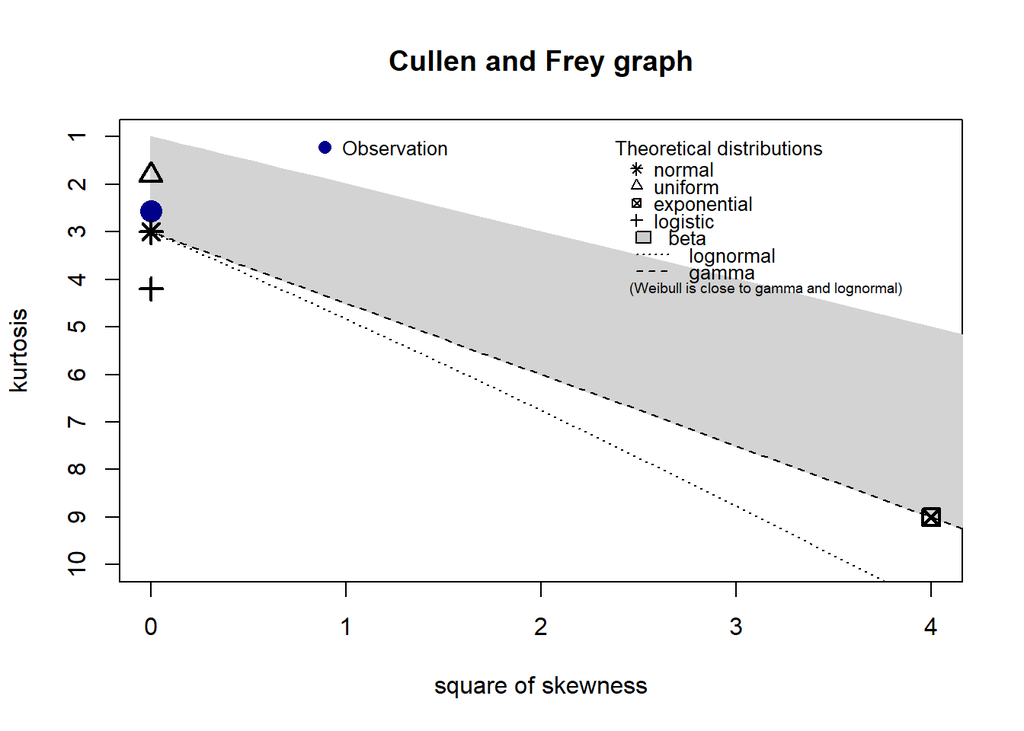

```
## summary statistics
## ------
## min:  -10   max:  10
## median:  0
## mean:  0
## estimated sd:  4.0996
## estimated skewness:  0
## estimated kurtosis:  2.564116
```

```r
#对c(1:5)的一种可能排列v,求出p(下标n)
pfun <- function(v, n){
  res <- 0
  for(k in n:4){
    h <- k + 1
    if(v[k] < v[h]){
      res <- res + 1
    }
  }
  return(res)
}

#对c(1:5)的一种可能排列v,求出q(下标n)
qfun <- function(v, n){
  res <- 0
  for(k in n:4){
    h <- k + 1
    if(v[k] > v[h]){
      res <- res + 1
    }
  }
  return(res)
}

x <- c(1:5)
library(gtools)
#allpermn为120*5矩阵，每一行是一种c(1:5)的一种可能排列，一共有120种可能排列
allpermn <- permutations(5, 5, 1:5)

#初始化p矩阵和q矩阵
#p,q均为120*4矩阵
#p[i,j]是第i中排列的p(下标j)值,q[i,j]是第i种排列的q(下标j)值
p <- matrix(0, nrow = 120, ncol = 4)
q <- matrix(0, nrow = 120, ncol = 4)
i <- 1
j <- 1
for(i in 1:120){
  for(j in 1:4){
#调用函数pfun和qfun求出p和q矩阵
    p[i,j] <- pfun(allpermn[i, ], j)
    q[i,j] <- qfun(allpermn[i, ], j)
  }
  j <- 1
}

#result1为120*4矩阵,result1[i,j]是第i种排列的p(下标j)-q(下标j)的值
result1 <- p-q
#result2为120*1矩阵,result2[i]是第i种排列的sum(pj-qj)的值
#result2即为由x构成的所有可能排列的计算结果
result2 <- apply(result1, 1, sum)

#下面判断其分布
#使用fitdistplus包中的descdist()函数,初步判断result2的分布
library(fitdistrplus)
#结果显示,数据更接近正态分布(在图中由星号表示)
descdist(result2)
```

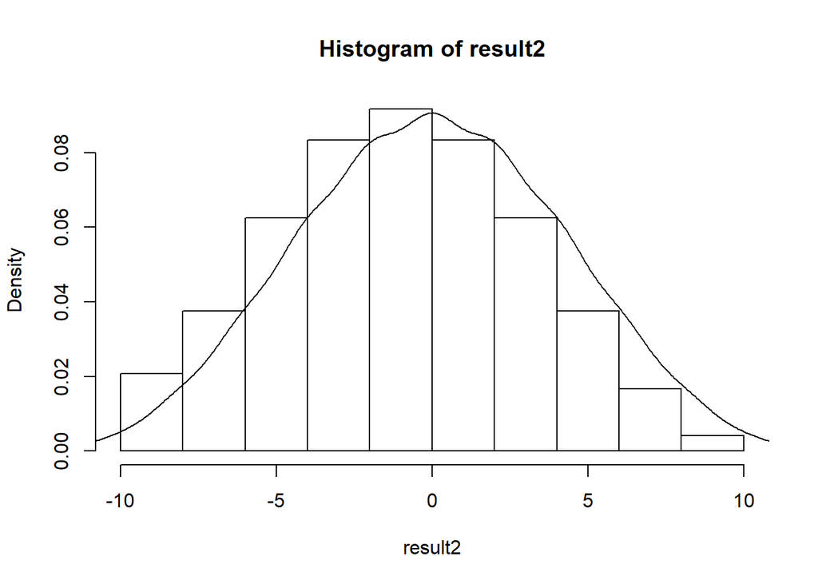

```r
#画出结果的直方图和密度曲线
hist(result2, freq = FALSE)
lines(density(result2))
```

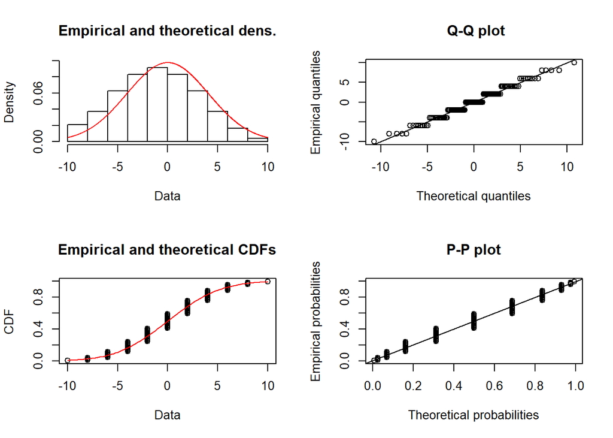

```r
#使用fitdist()函数,判断结果对正态分布的服从程度
normal_dist <- fitdist(result2, "norm")
plot(normal_dist)
```

```r
#得到结论
print('所有可能结果接近正态分布, 均值和标准差的极大似然估计为:')
```

```
## [1] "所有可能结果接近正态分布, 均值和标准差的极大似然估计为:"
```

```r
normal_dist
```

```
## Fitting of the distribution ' norm ' by maximum likelihood
## Parameters:
##      estimate Std. Error
## mean 0.000000  0.3726780
## sd   4.082483  0.2635231
```

## A.5

该方程在(-10,10)之间的根是x=2

```r
#使用二分法求f在(a,b)之间的零点,eps为精度
bisection <- function(f, a, b, eps=1e-10){
  if(f(a)*f(b) > 0)
    list(fail = "cannot find root")
  else{
    repeat{
#区间长度足够小时,认为a=b=函数f的零点
      if(abs(b - a) < eps)
        break;
#否则取(a,b)的中点x,将新区间取为(a,x)或(x,b),重复上述判断过程直至区间长度足够小
      x <- (a + b) / 2
      if(f(a)*f(x) < 0)
        b <- x
      else
        a <- x
    }
    list(root = (a + b) / 2)
  }
}
#f为待求方程的等号左边的函数
f <- function(x) 2 * x ^ 3 - 4 * x ^ 2 + 3 * x - 6
#求得方程的根
print("2*x^3-4*x^2+3*x-6 = 0在(-10,10)之间的根为:")
```

```
## [1] "2*x^3-4*x^2+3*x-6 = 0在(-10,10)之间的根为:"
```

```r
bisection(f, -10, 10)
```

```
## $root
## [1] 2
```

## A.9

```r
#将13个人编号
people <- 1:13
#只要圈里的人超过2个,就进行循环
while(length(people) > 2){
#去掉退出圈子的人,即报到3的人
  people <- c(tail(people, -3), people[1:2])
}
#循环结束时圈子里有2人,此时报号为2的人留下
print(people[2])
```

```
## [1] 13
```

## A.10

```r
#读入数据,并将每一列都作为numeric类别
score <- read.table(file = "D:/student.txt", header = TRUE, sep = "\t", stringsAsFactors = FALSE, encoding = "UTF-8", colClasses = c("character", "numeric", "numeric", "numeric", "numeric", "numeric"))

subjects <- c("math", "physics", "chem", "literat", "english")
score1 <- score[, 2:6]
#对每一行求均值，得到每个学生的平均成绩
meanscore <- apply(score1, 1, mean)
#将平均成绩作为最后一列加入数据集中
avescore <- cbind(score, meanscore)
print ('(2)加入平均成绩以后的学生成绩:')
```

```
## [1] "(2)加入平均成绩以后的学生成绩:"
```

```r
#以表格形式输出
knitr::kable(avescore, format = "html")
```

| name | math | physics | chem | literat | english | meanscore |
| --- | --- | --- | --- | --- | --- | --- |
| Katty | 65 | 61 | 72 | 84 | 79 | 72.2 |
| Leo | 77 | 77 | 76 | 64 | 55 | 69.8 |
| Ricky | 67 | 63 | 49 | 65 | 57 | 60.2 |
| Marry | 80 | 69 | 75 | 74 | 63 | 72.2 |
| Mark | 74 | 70 | 80 | 84 | 74 | 76.4 |
| Steven | 78 | 84 | 75 | 62 | 64 | 72.6 |
| Simon | 66 | 71 | 67 | 52 | 57 | 62.6 |
| Angel | 77 | 71 | 57 | 72 | 71 | 69.6 |
| Jed | 83 | 100 | 79 | 41 | 50 | 70.6 |
| Jack | 86 | 94 | 97 | 51 | 55 | 76.6 |
| Mike | 74 | 80 | 88 | 64 | 66 | 74.4 |
| Jetty | 67 | 84 | 53 | 58 | 56 | 63.6 |
| Corner | 81 | 62 | 69 | 56 | 52 | 64.0 |
| Osten | 71 | 64 | 94 | 52 | 52 | 66.6 |
| Liggle | 78 | 96 | 81 | 80 | 76 | 82.2 |
| Over | 69 | 56 | 67 | 75 | 80 | 69.4 |
| Charlie | 77 | 90 | 80 | 68 | 60 | 75.0 |
| Ellin | 84 | 67 | 75 | 60 | 63 | 69.8 |
| Ellen | 62 | 67 | 83 | 71 | 77 | 72.0 |
| Simke | 74 | 65 | 75 | 72 | 73 | 71.8 |
| Peter | 91 | 74 | 97 | 62 | 66 | 78.0 |
| Joke | 72 | 87 | 72 | 79 | 76 | 77.2 |
| Joe | 82 | 70 | 83 | 68 | 85 | 77.6 |
| Kanto | 63 | 70 | 60 | 91 | 82 | 73.2 |
| Amon | 74 | 79 | 95 | 59 | 59 | 73.2 |
| Aril | 66 | 61 | 77 | 62 | 64 | 66.0 |
| Bob | 90 | 82 | 98 | 47 | 60 | 75.4 |
| Joseph | 77 | 90 | 85 | 68 | 76 | 79.2 |
| Linda | 91 | 82 | 84 | 54 | 60 | 74.2 |
| Mirra | 78 | 84 | 100 | 51 | 60 | 74.6 |

```r
#通过which.max()函数得到平均分最高的学生的index
bestscore <- avescore[which.max(meanscore), ]
print ('(3)平均分的最高分对应的学生和他所修课程的成绩:')
```

```
## [1] "(3)平均分的最高分对应的学生和他所修课程的成绩:"
```

```r
knitr::kable(bestscore, format = "html")
```

|  | name | math | physics | chem | literat | english | meanscore |
| --- | --- | --- | --- | --- | --- | --- | --- |
| 15 | Liggle | 78 | 96 | 81 | 80 | 76 | 82.2 |

```r
#求出所有学生的不及格科目的数量
failnum <- rep(0,30)
for(i in 1:30){
  for(j in 1:5){
    if(score1[i, j] < 60){
      failnum[i] <- failnum[i] + 1
    }
  }
}
#初始化有至少两门课程不及格的学生的向量
failstu <- c()
#如果有学生有至少两门不及格,则加入向量failstu中
for(i in 1:30){
  if(failnum[i] >= 2){
    failstu <- append(failstu, i)
  }
}
failscore <- avescore[failstu, ]
print ('(4)至少两门课程不及格的学生的全部成绩和平均成绩:')
```

```
## [1] "(4)至少两门课程不及格的学生的全部成绩和平均成绩:"
```

```r
knitr::kable(failscore, format = "html")
```

|  | name | math | physics | chem | literat | english | meanscore |
| --- | --- | --- | --- | --- | --- | --- | --- |
| 3 | Ricky | 67 | 63 | 49 | 65 | 57 | 60.2 |
| 7 | Simon | 66 | 71 | 67 | 52 | 57 | 62.6 |
| 9 | Jed | 83 | 100 | 79 | 41 | 50 | 70.6 |
| 10 | Jack | 86 | 94 | 97 | 51 | 55 | 76.6 |
| 12 | Jetty | 67 | 84 | 53 | 58 | 56 | 63.6 |
| 13 | Corner | 81 | 62 | 69 | 56 | 52 | 64.0 |
| 14 | Osten | 71 | 64 | 94 | 52 | 52 | 66.6 |
| 25 | Amon | 74 | 79 | 95 | 59 | 59 | 73.2 |

```r
#求出有至少两门课程不及格的学生的平均分
failscore1 <- failscore[, 7]

#去除有至少两门课程不及格的学生以后,求剩余学生的平均分
succscore <- avescore[-failstu, ]
succscore1 <- succscore[, 7]

#使用t检验,来检验至少两门不及格的学生与其他学生的平均分是否有差异
t.test(failscore1 ,succscore1)
```

```
##
##  Welch Two Sample t-test
##
## data:  failscore1 and succscore1
## t = -3.0236, df = 9.3087, p-value = 0.01386
## alternative hypothesis: true difference in means is not equal to 0
## 95 percent confidence interval:
##  -11.493236  -1.684037
## sample estimates:
## mean of x mean of y
##  67.17500  73.76364
```

```r
print("p<0.05,由此得到")
```

```
## [1] "p<0.05,由此得到"
```

```r
print ('(5)至少两门不及格的学生与其他学生的平均分有差异')
```

```
## [1] "(5)至少两门不及格的学生与其他学生的平均分有差异"
```

## 1.9.4

通过估计量的方差来衡量估计量的有效性,方差更小者更有效。

结论显示,对于t3分布来说,样本中位数更有效。

```r
ave <- c()
med <- c()
#样本量为500,抽样500次
for(i in 1:500){
#自由度为3
  sample <- rt(500, 3)
  ave <- c(ave, mean(sample))
  med <- c(med, median(sample))
}
print("样本均值的方差")
```

```
## [1] "样本均值的方差"
```

```r
var(ave)
```

```
## [1] 0.006529449
```

```r
print("样本中位数的方差")
```

```
## [1] "样本中位数的方差"
```

```r
var(med)
```

```
## [1] 0.003637265
```

```r
if(var(ave)<var(med)){
  print("样本均值更有效")
}else{
  print("样本中位数更有效")
}
```

```
## [1] "样本中位数更有效"
```

## 1.9.8

太阳花图 (sunflower plot) 将数据点绘制成向日葵将, 相同的数据点用向日葵中的花瓣(叶子)表示, 花瓣的多少表示数据的密集程度。

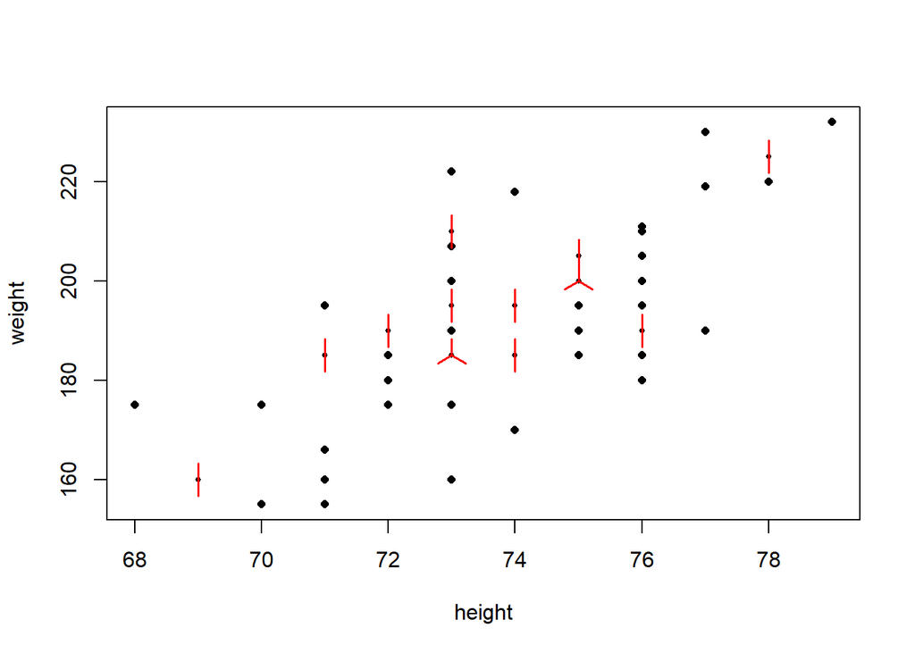

```r
library(Rfit)
attach(baseball)
#画出太阳花图,展示高度和重量之间的关系
sunflowerplot(height, weight)
```

```r
detach(baseball)
```

图中没有花瓣的点表示只有一个数据,有n个花瓣(n>=2)则表示这里有n个相同的数据。

由图中可以看出,高度和重量呈现大致的正相关关系,且高度和重量的分布都较为对称。

## 1.9.11

```r
#原假设
a <- 0
#标准差
s <- 1
n <- 25
#置信区间的长度(单侧假设检验),alpha=0.05
error <- qnorm(0.95)*s/sqrt(n)
#置信上限
right <- a + error
#均值mean的真实值
assumed <- a + 0.5
#根据公式求出检验的power
Zright <-(right - assumed)/(s/sqrt(n))
p <- pnorm(Zright)
print ('the power')
```

```
## [1] "the power"
```

```r
print(1-p)
```

```
## [1] 0.8037649
```

## 例1.1

### 1.分析泊松分布的犯第一类错误的概率随着λ的增大而减小

$X_{1}, X_{2}, \ldots X_{n}$ 服从独立同分布的参数为 $\lambda$ 的泊松分布，

则 $\sum_{i=1}^{n} X_{i}$ 服从参数为 $n \lambda$ 的泊松分布。

记 $Y=\sum_{i=1}^{n} X_{i} \quad$ , 则有

$P\left(\sum_{i=1}^{n} X_{i} \leq C\right)=P(Y \leq C)=\sum_{k=0}^{C} \frac{(n \lambda)^{k} e^{-n \lambda}}{k !}=\int_{n}^{+\infty} \frac{\lambda^{C+1} x^{C} e^{-\lambda x}}{\Gamma(C+1)} d x$

当 $\lambda$ 增大时, $\int_{a}^{+\infty} \frac{(n \lambda)^{a} e^{-(n \lambda) z} z^{a}}{\Gamma(a+1)} d z$ 减小 , 即

$P\left(\sum_{i=1}^{n} x_{i} \leq a\right)$ 减小

从而泊松分布犯第 I 类错误的概率

$\alpha(\lambda)=P($ 拒绝零假设|零假设为真 $)=P\left(\sum_{i=1}^{n} X_{i}<C \mid \lambda \in H_{0}\right)$

随着 $\lambda$ 的增大而减小。

### 2.画出势函数变化的曲线图

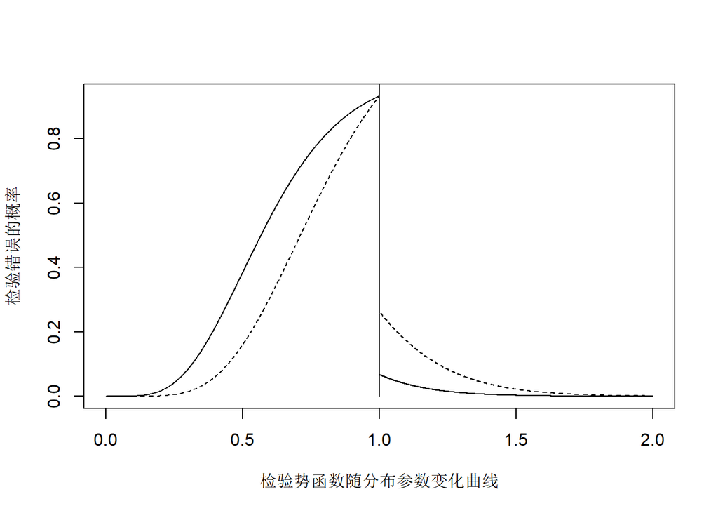

```r
#样本量
n <- 10

#lambda>1时的alpha(lambda)
func1 <- function(lambda1, c1){
  alpha <- ppois(c1, lambda = n*lambda1)
  return(alpha)
}

#lambda<1时的beta(lambda)
func2 <- function(lambda2, c2){
  beta <- ppois(c2, lambda = n*lambda2)
  return(1-beta)
}

#以lambda=1为分界,求出C=5时的势函数
y1 <- function(x){
  return(ifelse(x>1,func1(x, 5),func2(x, 5)))
}
#以lambda=1为分界,求出C=7时的势函数
y2 <- function(x){
  return(ifelse(x>1,func1(x, 7),func2(x, 7)))
}

#画出C=5时的势函数曲线
curve(expr = y1, xlim = c(0, 2), n = 10000, xlab="检验势函数随分布参数变化曲线", ylab="检验错误的概率")
#画出C=7时的势函数曲线
par(new=T)
curve(expr = y2, xlim = c(0, 2), n = 10000, lty=2, yaxt="n", xaxt="n", xlab="", ylab="")
lines(c(1,1),c(0,1))
```